# Is there any inequality in prision system in the United States?

Yeji Kim

2022-11-01

## Introduction

There is a potential inequality in the prison system in the United States. The prevalent racism causes the disproportionate incarceration of people of color by creating stereotypes in the crime scene and this results in over-policing of them. For instance, black people are twice as likely to be arrested as white people. Why does this happen in society? The direct stakeholders who are people in power are less aware of the criminalization and racial disparity and therefore their authority supposed to resolve the unequal social and political structures are not yet widely used. Moreover, Vera’s work showed that people behind bars are less likely to be given opportunities for growth, such as higher education and job opportunities. This can indirectly influence people inside the bars where exceeding racial disparity causes less public safety so they also need to work for racial inequality in the prison system.

## Data Summary

The max black jail population in a county in the year 2018 is **5024** while the max white jail population in the same year is **4577**. In the different year 2000, the max black jail population in a county is **8090** whereas the max white jail population is **4174**. Although there are more white people in the United States, the numbers show that there are more black people in jail.

## Chart 1:

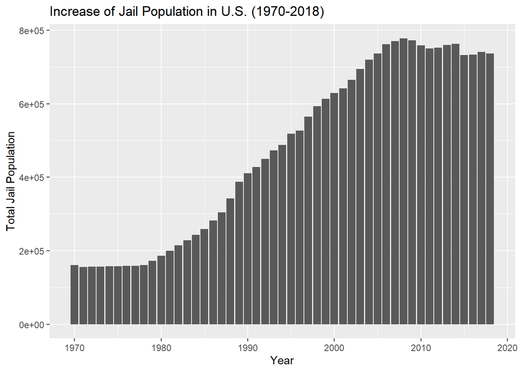

**Figure 1**: The jail population in the United States has been increased from 1970 to 2018.

The graph shows that there is about four times greater jail population in 2018 compared to 1970. The jail population from 1970 to 1980 had minimal difference but it began to dramatically increase since 1980. It peaked around the late 2000s and remained almost consistent until 2018.

## Chart2:

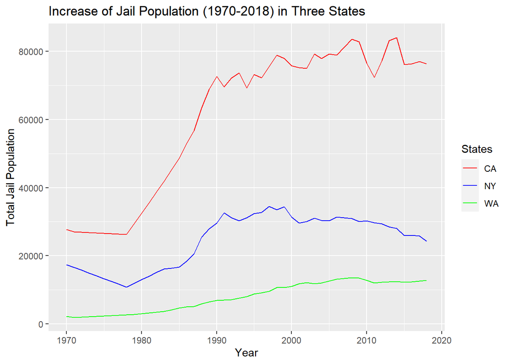

The graph shows that the jail population in all three states – Washington, New York, and California - increased in about 50 years. However, there were about 10,000 people differences in jail population between New York and California in 1970 but that of 2018 became five times larger. This shows that the most dramatic increase happened in California.

## Chart3:

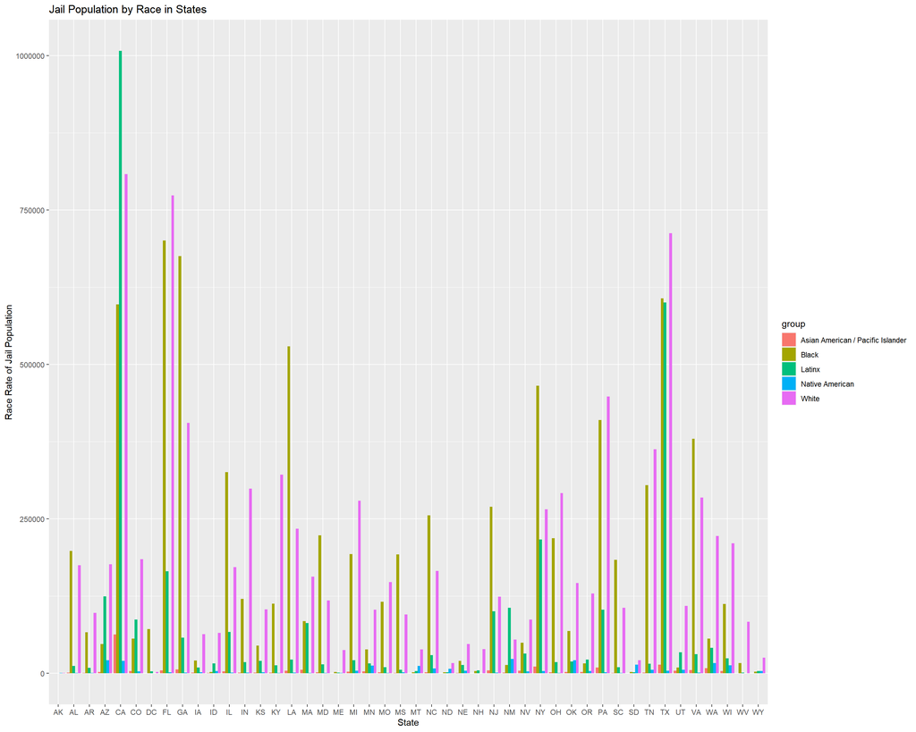

**Figure 3**: The jail population by race is disproportionately distributed in the states.

To figure out if there is a racial disproportion in prison systems in each state, the graph shows how the jail population differs by race in them. Despite consideration of the white population majority in the United States, many states show that either black or Latinx either outnumber or have a similar jail population as white. Asian Americans or Pacific Islanders usually have a small proportion in most states. Native American jail populations vary in each state.